# Dissertation

Imogen Whitehead

# 1 Introduction

This data set is formed from recordings taken by multiple ships between the years 1886-2016.

Fish were taken from some location, and their individual stomach contents recorded. Predators of the same species and (roughly) the same weight/size were recorded as a single data point (the number of predators for each data set is called ‘n_stomachs’). Prey of (roughly) the same size found in these stomachs were recorded in this same data point, and the total number of prey in some data point is called ‘prey_count’. For each individual data point,

$$\text{no. prey per stomach} = \frac{\text{no. of stomachs
sampled}}{\text{total no. of prey}}$$
This is an aproximation of the number of prey per stomach for some specific predator, and is called ’ no._prey_per_stmch’.

Using similar logic,‘prey_weight_g’ is the total weight of prey in the multiple stomachs sampled to make up one datapoint. ‘indiv_prey_weight’ is then the weight of one single prey individual found in the stomach

# 2 Distribution of prey type eaten for each predator

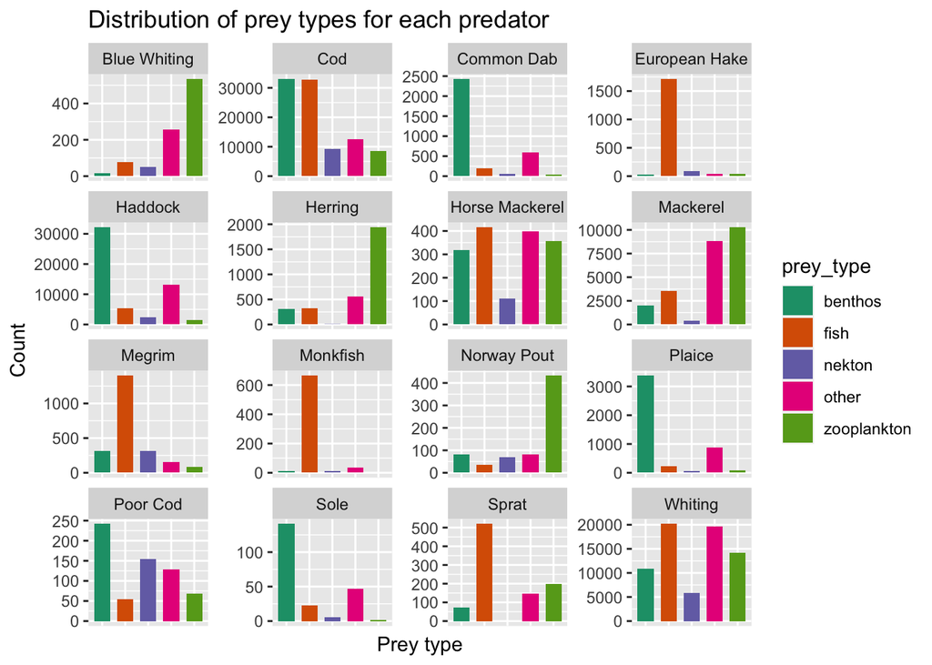

These are individual bar charts showing the distribution of the type of prey each predator eats.

The prey types are:

- Benthos: organisms that live on/near the bottom of a body of water
- Fish: aquatic, craniate (have a skull), gill-bearing animals that lack limbs with digits (i.e. their limbs don’t have toes or fingers)
- Nekton: the actively swimming aquatic organisms
- Other: misc. types that don’t fit into the other categories
- Zooplankton: animal plankton (plankton are aquatic organisms that are unable to swim effectively against currents)

# 3 Average PPMR for individual species

Here, we are looking for the most common log(PPMR) for each individual species. This will be done by plotting log(PPMR) against the density of points, and weighting observations on different variables.

## 3.1 Weighted by prey biomass:

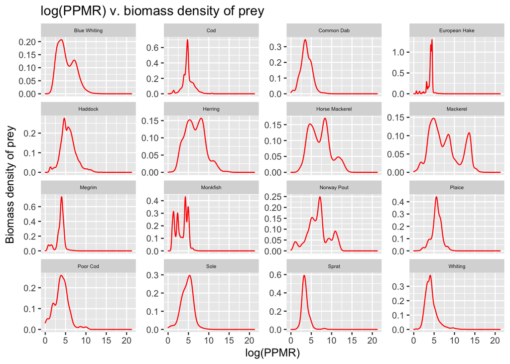

These plots are weighted by the prey biomass. This means that we are looking at the distribution of prey biomass across values of log(PPMR), so points with a larger biomass are prioritised/weighted more than those with a smaller biomass.

## 3.2 Weighted by number of prey:

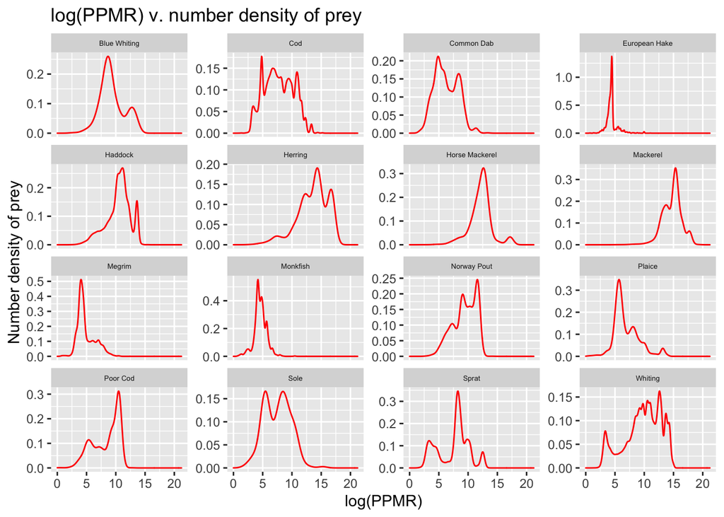

These plots are weighted by the number pf prey per stomach. This means that data points with a larger number of prey per stomach are prioritised/weighted more than those with a smaller number of prey per stomach.

# 4 Specific PPMR calculations by different weightings for Herring species

## 4.1 Weighted by prey biomass

```
## [1] "log(ppmr) mean, weighted by biomass of prey: 6.62917673459157"
```

```
## [1] "Standard deviation of this: 2.3508789268221"
```

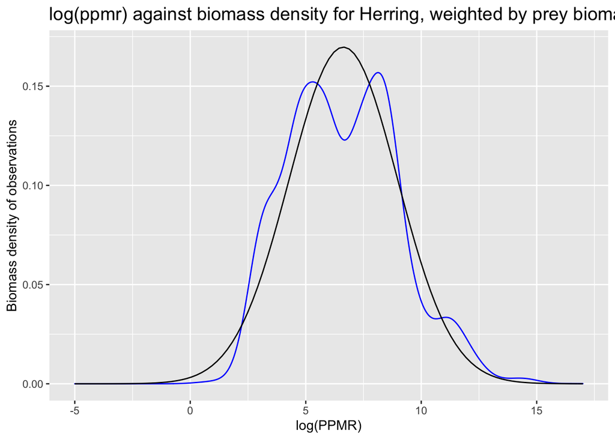

The curve with points weighted by the prey biomass is plotted in blue, and a normal curve (also weighted by prey biomasss) is plotted over the top in black.

## 4.2 Weighted by number of prey

```
## [1] "log(ppmr) mean, weighted by number of observations: 13.5410236346048"
```

```
## [1] "Standard deviation of this: 2.63330496940788"
```

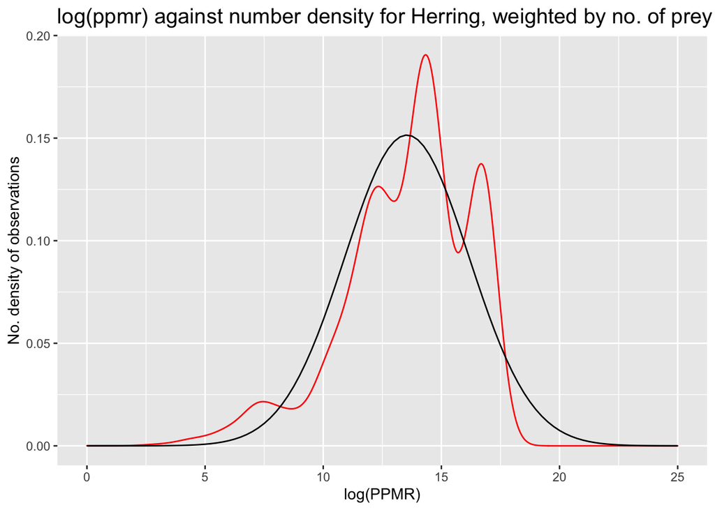

The curve with points weighted by the number of prey per stomach is plotted in red, and a normal curve (also weighted by the number of prey per stomach) is plotted over the top in black.

## 4.3 Combined graph

[figure not shown]

This is a graph with both the the distribution of Herring log(PPMR) as weighted by prey biomass and number of prey plotted over each other (along with appropriately weighted normal distribution curves plotted over the top of each).

Prey biomass weighted mean: 6.629177 No. of prey weighted mean: 13.54102

Prey biomass standard deviation: 2.3508789268221 No. of prey standard deviation: 2.63330496940788

The mean is shifted by 6.911843.

The mathematics of shifted means for this difference in weighting is:

$$\text{expected prey biomass weighted mean} = \text{no. of prey
weighted mean} - (\text{no. of prey standard deviation})^2$$

# 5 Most common prey weights

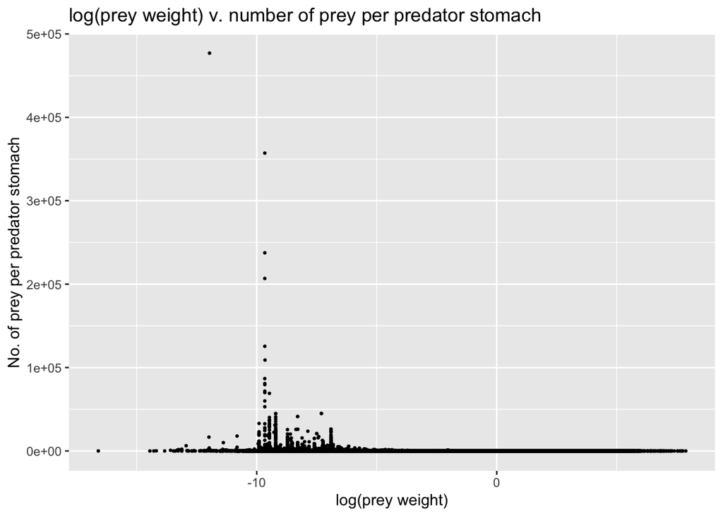

This graph is looking at the distribution of the weight of prey recorded, i.e. looking at what is the most common prey weight over all prey species. It is a graph over all the data points, so includes recordings from all the ships involved.

There are some potentially interesting results, so results from different ships were plotted on individual curves to further look into these results.

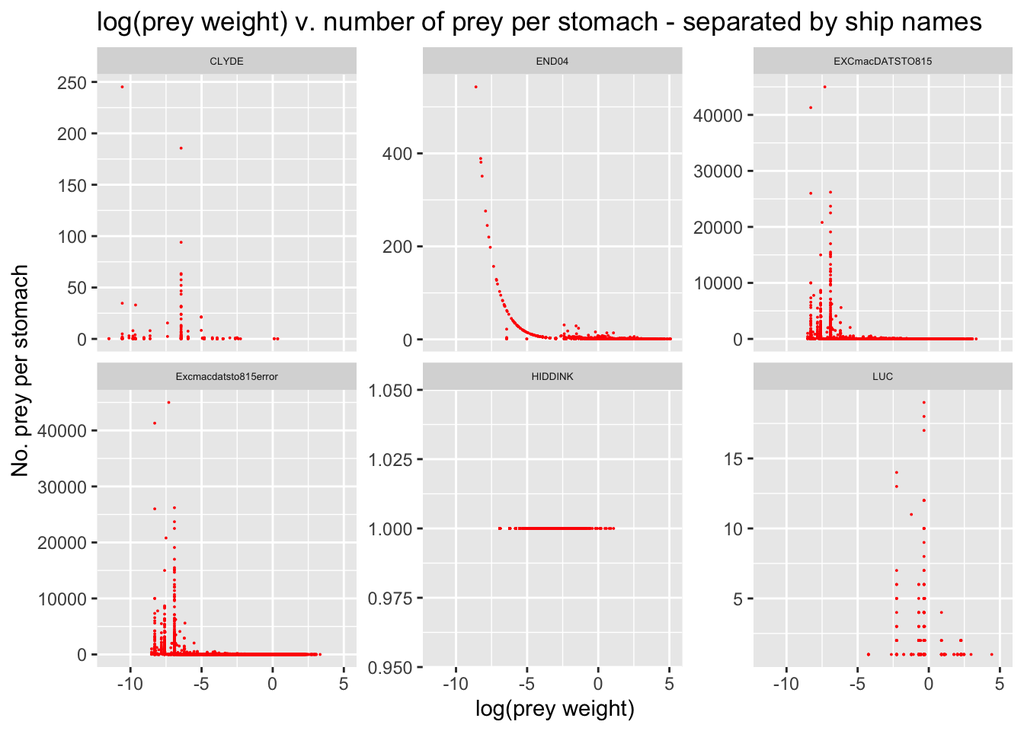

These six graphs show a range of unusual looking points:

1. $y \propto e^-x$ relation for END04 (i.e. no. per stomach is proportional to 1/prey weight)
2. lots of observations for single prey weights for LUC and CLYDE
3. lots of the same no. of prey per stomach observations for HIDDINK.
4. the EXCmacDATSTO815 and Excmacdatsto815error seem to represent exactly the same data

# 6 Prey and predator weight relation

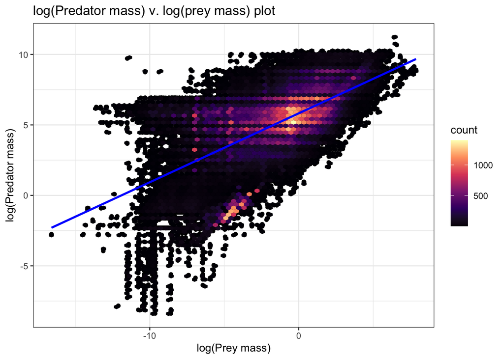

```
## [1] "slope of the log(pred) v. log(prey) line of best fit: 0.489336522809739"
```

Attempting to find a link between the predator mass and the prey mass. Log() of each axis is used to see the proportionality of the axes, where the slope of the added line should = 1. This is because:

$$\text{log(pred weight)} = m * \text{log(prey weight)} + c$$

Where m is the gradient of the slope and c is the y-intercept (thinking of this graph as a linear model).

Taking the exponential of both sides,

$$\text{pred weight} = exp^{m*\text{log(preyweight)}} + log(D)$$
where log(d) = c.

Finally,

$$\text{pred weight} = \text{prey weight}^m * D$$

Hence, we want m=1 to show that pred weight proportional to prey weight (as expected).

For this graph, the slope is not equal to one. However, this graph is plotted over the entire data set and includes values from all of the available predator species.

Instead, separate the plots by predator species to see if there is some proportionality between the predator and prey weight for each specific species.

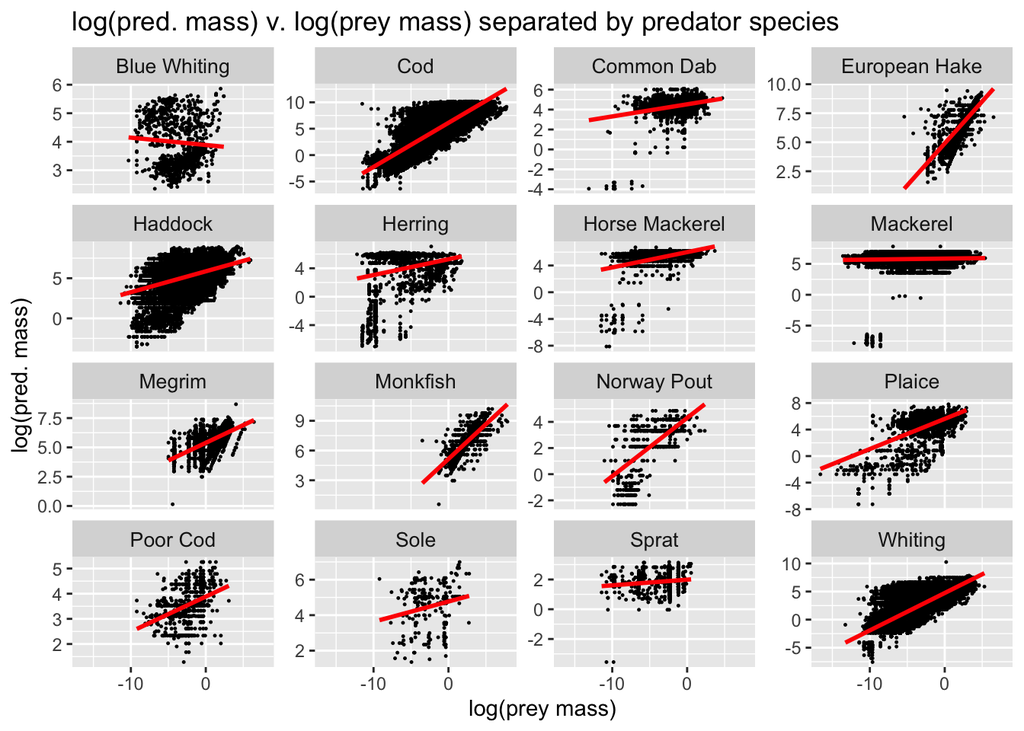

Here, we are splitting up the graphs over each individual predator species to look and see if there is a proportionality for each specific species.

# 7 Predator weight against ppmr

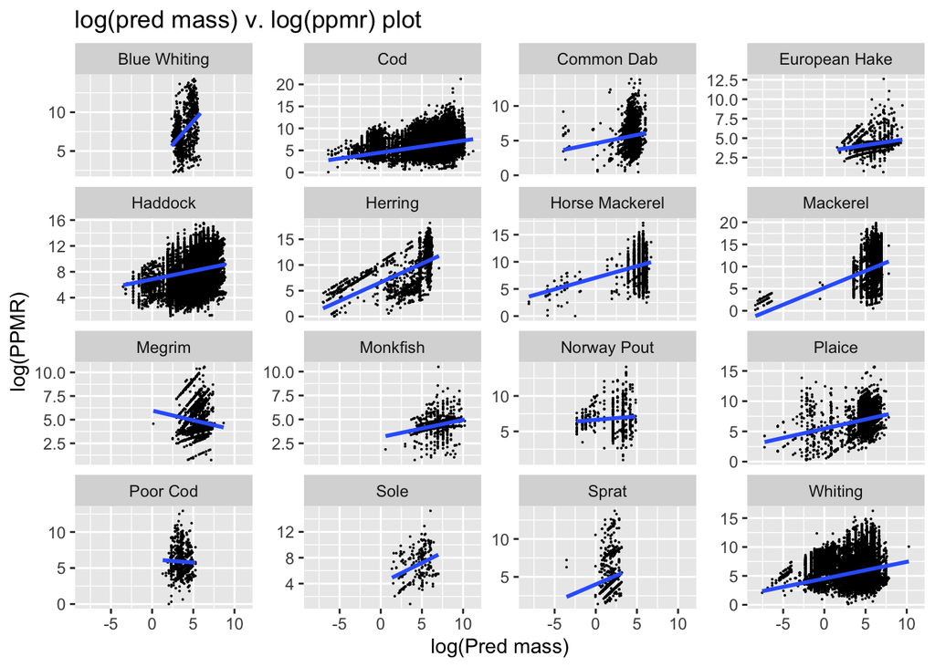

Graphing log(pred mass) v. log(ppmr) for individual predator species to see if the predator mass related to the ppmr.

We want them to not be proportional (i.e. slope, m= 0) to prove that log(predator mass) is not related to the log(ppmr) (and hence the ppmr is independent of the predator mass for a certain species).

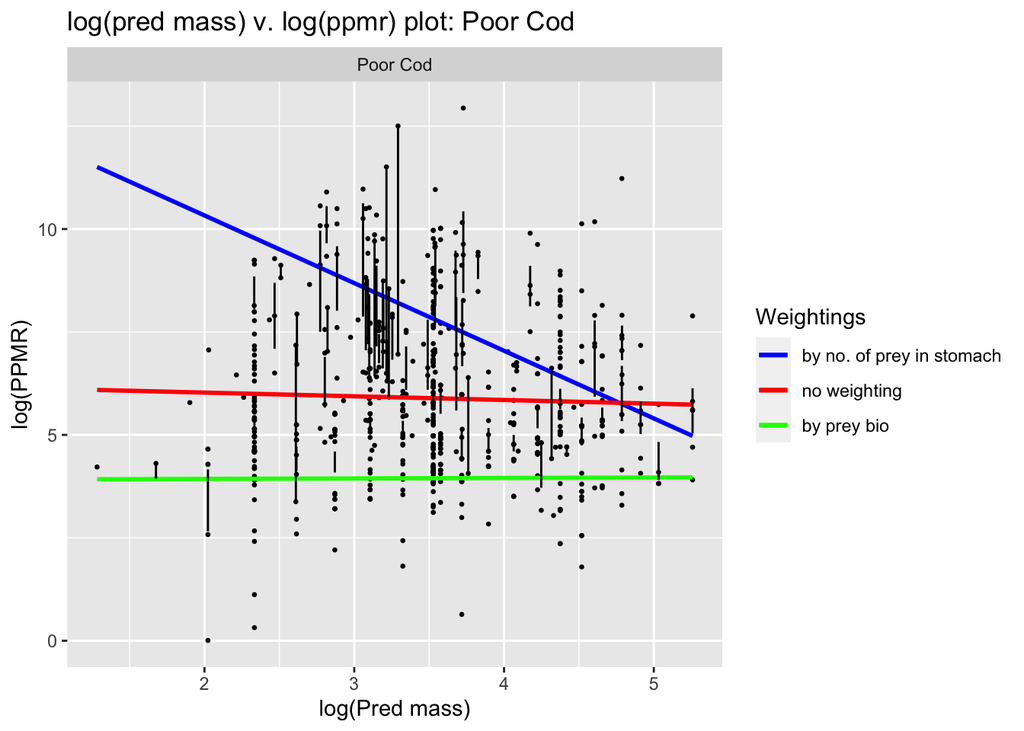

```
## [1] "slope of the log(ppmr) v. log(pred_weight) line of best fit for poor cod:"
```

```
## [1] "i) Weighted by no prey in the stomach: -1.64313946193691"
```

```
## [1] "ii) No weighting in the calculation: -0.0895529388001952"
```

```
## [1] "iii) Weighted by prey biomass: 0.0116668819369047"
```

Looking at just the predator species ‘poor cod’. There are three LOBF (line of best fit), weighted by different variables:

1. blue: by number of prey per stomach
2. red: no weighting in the LOBF
3. green: by prey biomass

# 8 Introducing a mixed effects model

```
## Linear mixed model fit by maximum likelihood  ['lmerMod']
## Formula: lppmr ~ pred_species + prey_weight_g + (1 | haul_id_short)
##    Data: renamed_df
##       AIC       BIC    logLik  deviance  df.resid
## 1118423.8 1118623.2 -559192.9 1118385.8    267412
## Random effects:
##  Groups        Name        Std.Dev.
##  haul_id_short (Intercept) 1.654
##  Residual                  1.956
## Number of obs: 267431, groups:  haul_id_short, 110
## Fixed Effects:
##                (Intercept)             pred_speciesCod
##                   5.109624                    1.413460
##     pred_speciesCommon Dab   pred_speciesEuropean Hake
##                   0.980939                   -0.578122
##        pred_speciesHaddock         pred_speciesHerring
##                   1.915679                    1.617804
## pred_speciesHorse Mackerel        pred_speciesMackerel
##                   1.930366                    1.970129
##         pred_speciesMegrim        pred_speciesMonkfish
##                  -0.120946                   -0.278749
##    pred_speciesNorway Pout          pred_speciesPlaice
##                   2.073627                    2.128007
##       pred_speciesPoor Cod            pred_speciesSole
##                   0.647957                    1.740834
##          pred_speciesSprat         pred_speciesWhiting
##                   0.418947                    0.810650
##              prey_weight_g
##                  -0.003506
```

```
## Linear mixed model fit by REML ['lmerMod']
## Formula: lppmr ~ pred_species + prey_weight_g + (1 | haul_id_short) +
##     (1 | year) + (1 | no._prey_per_stmch) + (1 | ices_rectangle)
##    Data: renamed_df
## REML criterion at convergence: 1023959
## Random effects:
##  Groups             Name        Std.Dev.
##  no._prey_per_stmch (Intercept) 1.7994
##  ices_rectangle     (Intercept) 0.6634
##  year               (Intercept) 0.6564
##  haul_id_short      (Intercept) 1.6903
##  Residual                       1.7773
## Number of obs: 254595, groups:
## no._prey_per_stmch, 4507; ices_rectangle, 718; year, 97; haul_id_short, 97
## Fixed Effects:
##                (Intercept)             pred_speciesCod
##                   7.354137                    1.336221
##     pred_speciesCommon Dab   pred_speciesEuropean Hake
##                   0.500668                   -0.098397
##        pred_speciesHaddock         pred_speciesHerring
##                   1.582278                    1.008104
## pred_speciesHorse Mackerel        pred_speciesMackerel
##                   1.393272                    1.341490
##         pred_speciesMegrim        pred_speciesMonkfish
##                   0.432421                   -0.132208
##    pred_speciesNorway Pout          pred_speciesPlaice
##                   1.510116                    1.853671
##       pred_speciesPoor Cod            pred_speciesSole
##                   0.512387                    1.706721
##          pred_speciesSprat         pred_speciesWhiting
##                   0.030321                    0.870806
##              prey_weight_g
##                  -0.004578
## optimizer (nloptwrap) convergence code: 0 (OK) ; 0 optimizer warnings; 1 lme4 warnings
```

Linear (fixed) effects: pred_species, prey_weight_g (what we assume will affect the fixed effect)